# 05 - Summary: can genomic selection improve nitrogen use efficiency?

# 7 Breeding programmes over time (file 04)

```r
trend <- rbindlist(lapply(scen, function(s) rd(sprintf("gs_trend_%s.csv", s))), fill = TRUE)
beq   <- rbindlist(lapply(scen, function(s) rd(sprintf("gs_breeders_equation_%s.csv", s))), fill = TRUE)
idx   <- rbindlist(lapply(scen, function(s) rd(sprintf("gs_index_correlations_%s.csv", s))), fill = TRUE)
Fdt   <- rbindlist(lapply(scen, function(s) rd(sprintf("gs_inbreeding_%s.csv", s))), fill = TRUE)
t0    <- rd("trend_burnin.csv")
tr_all <- rbind(rbindlist(lapply(scen, function(s) cbind(scenario = s, t0))), trend, fill = TRUE)
tr_all[, scenario := factor(scenario, scen)]
```

## 7.1 Mean and variance of genetic and phenotypic values

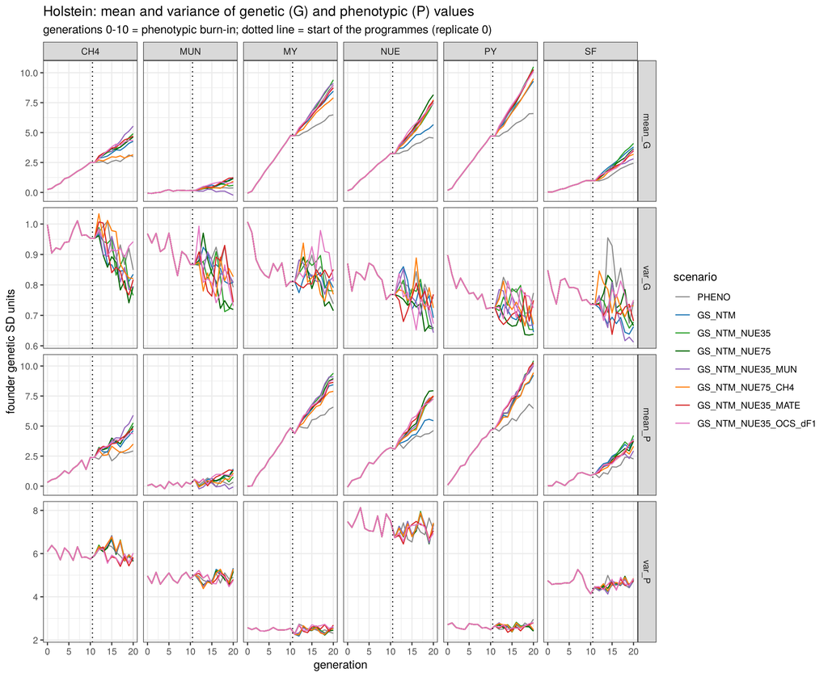

```r
key <- c("NUE", "MUN", "CH4", "MY", "PY", "SF")
long <- melt(tr_all[trait %in% key & breed == "HOL"],
             id.vars = c("scenario", "generation", "breed", "trait"))
ggplot(long, aes(generation, value, colour = scenario)) + geom_line() +
  geom_vline(xintercept = max(t0$generation) + 0.5, lty = 3) + scale_colour_manual(values = pal) +
  facet_grid(variable ~ trait, scales = "free_y") + theme_bw() +
  labs(title = "Holstein: mean and variance of genetic (G) and phenotypic (P) values",
       subtitle = "generations 0-10 = phenotypic burn-in; dotted line = start of the programmes (replicate 0)",
       y = "founder genetic SD units")
```

```r
fin <- tr_all[generation == max(generation) & trait %in% c(key, "SCS", "LNVAR", "ICF", "LONG")]
kable(dcast(fin, breed + trait ~ scenario, value.var = "mean_G"), digits = 2,
      caption = "Mean genetic value in the final generation")
```

Mean genetic value in the final generation

| breed | trait | PHENO | GS_NTM | GS_NTM_NUE35 | GS_NTM_NUE75 | GS_NTM_NUE35_MUN | GS_NTM_NUE75_CH4 | GS_NTM_NUE35_MATE | GS_NTM_NUE35_OCS_dF1 |
| --- | --- | --- | --- | --- | --- | --- | --- | --- | --- |
| HOL | CH4 | 2.99 | 4.27 | 4.91 | 4.64 | 5.54 | 3.14 | 4.71 | 4.33 |
| HOL | ICF | 0.15 | 1.21 | 2.02 | 2.50 | 2.14 | 2.08 | 1.71 | 1.63 |
| HOL | LNVAR | 2.51 | 2.23 | 2.97 | 2.60 | 2.92 | 2.18 | 2.57 | 2.79 |
| HOL | LONG | 1.78 | 2.11 | 3.07 | 3.64 | 2.94 | 3.83 | 3.64 | 3.36 |
| HOL | MUN | 0.37 | 1.26 | 0.59 | 1.16 | -0.23 | 0.93 | 1.22 | 0.82 |
| HOL | MY | 6.49 | 8.46 | 9.41 | 8.96 | 9.11 | 7.90 | 8.74 | 8.96 |
| HOL | NUE | 4.55 | 5.67 | 7.49 | 8.16 | 7.64 | 7.74 | 7.67 | 7.44 |
| HOL | PY | 6.59 | 9.30 | 10.49 | 10.25 | 10.09 | 9.50 | 10.27 | 10.12 |
| HOL | SCS | 1.19 | 1.49 | 2.22 | 1.94 | 2.43 | 1.89 | 2.52 | 1.91 |
| HOL | SF | 2.44 | 3.80 | 4.10 | 3.64 | 2.81 | 3.19 | 3.48 | 3.58 |
| JER | CH4 | 2.45 | 3.79 | 3.36 | 3.53 | 3.51 | 2.61 | 3.91 | 3.15 |
| JER | ICF | 1.72 | 3.31 | 2.06 | 2.23 | 2.85 | 2.80 | 2.83 | 2.84 |
| JER | LNVAR | 2.12 | 2.99 | 2.44 | 2.85 | 2.90 | 2.64 | 3.17 | 3.50 |
| JER | LONG | 1.93 | 2.68 | 3.44 | 3.77 | 3.22 | 3.97 | 3.16 | 2.61 |
| JER | MUN | 1.11 | 1.10 | 1.40 | 0.31 | -0.48 | 0.93 | 0.74 | 1.21 |
| JER | MY | 6.44 | 8.99 | 8.54 | 8.49 | 8.21 | 7.90 | 8.58 | 8.74 |
| JER | NUE | 4.62 | 7.19 | 7.21 | 7.63 | 7.28 | 7.68 | 7.04 | 6.65 |
| JER | PY | 6.88 | 10.03 | 9.79 | 9.71 | 9.37 | 9.19 | 9.67 | 9.49 |
| JER | SCS | -0.05 | 2.10 | 1.34 | 1.34 | 1.87 | 0.82 | 1.61 | 1.81 |
| JER | SF | 3.77 | 5.04 | 5.36 | 4.45 | 4.79 | 4.68 | 4.48 | 5.23 |
| RDC | CH4 | 3.01 | 3.69 | 3.48 | 3.26 | 3.42 | 2.14 | 3.90 | 3.76 |
| RDC | ICF | 1.95 | 2.83 | 2.88 | 3.13 | 3.40 | 2.47 | 3.25 | 2.89 |
| RDC | LNVAR | 2.63 | 3.73 | 3.76 | 3.54 | 3.97 | 3.76 | 3.71 | 3.67 |
| RDC | LONG | 0.87 | 1.31 | 1.37 | 2.00 | 1.42 | 2.06 | 0.89 | 1.64 |
| RDC | MUN | 0.42 | 0.08 | -0.06 | 0.39 | -0.29 | 0.24 | -0.70 | 0.28 |
| RDC | MY | 6.64 | 9.13 | 9.16 | 8.52 | 8.98 | 8.62 | 9.47 | 8.90 |
| RDC | NUE | 4.06 | 5.88 | 6.07 | 6.29 | 6.08 | 6.39 | 5.94 | 5.82 |
| RDC | PY | 6.64 | 9.11 | 9.08 | 9.02 | 8.90 | 8.80 | 9.17 | 8.96 |
| RDC | SCS | 1.16 | 1.47 | 1.42 | 1.89 | 1.31 | 1.68 | 1.25 | 0.60 |
| RDC | SF | 2.59 | 3.14 | 3.38 | 2.94 | 2.76 | 3.53 | 3.45 | 2.95 |

```r
gain <- merge(tr_all[generation == max(t0$generation), .(breed, trait, scenario, start = mean_G)],
              tr_all[generation == max(generation), .(breed, trait, scenario, end = mean_G)])
gain[, response := end - start]
kable(dcast(gain[trait %in% key], breed + trait ~ scenario,
            value.var = "response"), digits = 2,
      caption = "Response over the 10 selection generations (end minus last burn-in generation), replicate 0")
```

Response over the 10 selection generations (end minus last burn-in generation), replicate 0

| breed | trait | PHENO | GS_NTM | GS_NTM_NUE35 | GS_NTM_NUE75 | GS_NTM_NUE35_MUN | GS_NTM_NUE75_CH4 | GS_NTM_NUE35_MATE | GS_NTM_NUE35_OCS_dF1 |
| --- | --- | --- | --- | --- | --- | --- | --- | --- | --- |
| HOL | CH4 | 0.48 | 1.77 | 2.41 | 2.13 | 3.04 | 0.64 | 2.21 | 1.82 |
| HOL | MUN | 0.22 | 1.10 | 0.44 | 1.00 | -0.39 | 0.77 | 1.06 | 0.66 |
| HOL | MY | 1.74 | 3.71 | 4.66 | 4.21 | 4.36 | 3.15 | 3.99 | 4.21 |
| HOL | NUE | 1.29 | 2.41 | 4.24 | 4.91 | 4.39 | 4.49 | 4.41 | 4.19 |
| HOL | PY | 1.88 | 4.59 | 5.78 | 5.54 | 5.38 | 4.79 | 5.56 | 5.41 |
| HOL | SF | 1.46 | 2.81 | 3.11 | 2.65 | 1.82 | 2.20 | 2.49 | 2.59 |
| JER | CH4 | 0.77 | 2.10 | 1.67 | 1.85 | 1.83 | 0.92 | 2.22 | 1.46 |
| JER | MUN | 0.87 | 0.86 | 1.17 | 0.08 | -0.71 | 0.70 | 0.51 | 0.98 |
| JER | MY | 1.54 | 4.08 | 3.63 | 3.58 | 3.30 | 2.99 | 3.67 | 3.84 |
| JER | NUE | 1.18 | 3.75 | 3.78 | 4.20 | 3.84 | 4.24 | 3.60 | 3.21 |
| JER | PY | 2.16 | 5.32 | 5.08 | 4.99 | 4.66 | 4.48 | 4.96 | 4.78 |
| JER | SF | 1.60 | 2.87 | 3.19 | 2.28 | 2.62 | 2.51 | 2.30 | 3.06 |
| RDC | CH4 | 1.37 | 2.05 | 1.84 | 1.62 | 1.78 | 0.50 | 2.27 | 2.13 |
| RDC | MUN | 0.64 | 0.30 | 0.17 | 0.61 | -0.07 | 0.46 | -0.48 | 0.51 |
| RDC | MY | 1.77 | 4.26 | 4.29 | 3.65 | 4.11 | 3.75 | 4.60 | 4.03 |
| RDC | NUE | 1.77 | 3.60 | 3.79 | 4.01 | 3.80 | 4.11 | 3.66 | 3.53 |
| RDC | PY | 2.66 | 5.13 | 5.10 | 5.03 | 4.92 | 4.81 | 5.19 | 4.98 |
| RDC | SF | 1.74 | 2.29 | 2.53 | 2.09 | 1.91 | 2.68 | 2.60 | 2.09 |

## 7.2 Breeder’s equation: expected vs observed response

```r
beq[, dG_observed := shift(meanH, type = "lead") - meanH, by = .(scenario, breed)]
kable(beq[, .(i_sires_theory = mean(i_male_theory), i_sires = mean(i_male_obs),
              i_dams_of_sons = mean(i_elite_obs), i_dams_of_daughters = mean(i_female_obs),
              r_m = mean(r_male), r_f = mean(r_female), S_male = mean(S_male),
              dG_expected = mean(dG_expected), dG_observed = mean(dG_observed, na.rm = TRUE)),
          by = .(scenario, breed)], digits = 3,
      caption = "Selection intensity (i), selection differential (S), accuracy (r), expected and observed response per generation (each scenario's own index)")
```

Selection intensity (i), selection differential (S), accuracy (r), expected and observed response per generation (each scenario’s own index)

| scenario | breed | i_sires_theory | i_sires | i_dams_of_sons | i_dams_of_daughters | r_m | r_f | S_male | dG_expected | dG_observed |
| --- | --- | --- | --- | --- | --- | --- | --- | --- | --- | --- |
| PHENO | HOL | 2.892 | 3.820 | 1.555 | 0.349 | 0.075 | 0.399 | 3.689 | 0.314 | 0.297 |
| PHENO | RDC | 2.896 | 3.985 | 1.555 | 0.350 | 0.089 | 0.439 | 4.102 | 0.417 | 0.416 |
| PHENO | JER | 2.888 | 4.016 | 1.554 | 0.350 | 0.080 | 0.400 | 4.029 | 0.343 | 0.393 |
| GS_NTM | HOL | 2.892 | 2.834 | 1.547 | 0.351 | 0.349 | 0.358 | 1.426 | 0.594 | 0.645 |
| GS_NTM | RDC | 2.896 | 2.845 | 1.558 | 0.350 | 0.360 | 0.369 | 1.516 | 0.674 | 0.690 |
| GS_NTM | JER | 2.888 | 2.840 | 1.553 | 0.351 | 0.335 | 0.349 | 1.345 | 0.574 | 0.612 |
| GS_NTM_NUE35 | HOL | 2.892 | 2.909 | 1.559 | 0.349 | 0.406 | 0.411 | 1.619 | 0.859 | 0.871 |
| GS_NTM_NUE35 | RDC | 2.896 | 2.885 | 1.560 | 0.349 | 0.367 | 0.385 | 1.674 | 0.828 | 0.833 |
| GS_NTM_NUE35 | JER | 2.888 | 2.831 | 1.552 | 0.350 | 0.395 | 0.414 | 1.499 | 0.821 | 0.825 |
| GS_NTM_NUE75 | HOL | 2.892 | 2.878 | 1.559 | 0.349 | 0.395 | 0.410 | 1.792 | 1.017 | 1.033 |
| GS_NTM_NUE75 | RDC | 2.896 | 2.906 | 1.558 | 0.349 | 0.378 | 0.392 | 1.852 | 1.030 | 0.984 |
| GS_NTM_NUE75 | JER | 2.888 | 2.864 | 1.548 | 0.351 | 0.383 | 0.394 | 1.693 | 0.959 | 0.970 |
| GS_NTM_NUE35_MUN | HOL | 2.892 | 2.864 | 1.555 | 0.350 | 0.368 | 0.385 | 1.620 | 0.756 | 0.772 |
| GS_NTM_NUE35_MUN | RDC | 2.896 | 2.876 | 1.556 | 0.350 | 0.337 | 0.355 | 1.609 | 0.748 | 0.768 |
| GS_NTM_NUE35_MUN | JER | 2.888 | 2.804 | 1.550 | 0.351 | 0.356 | 0.373 | 1.520 | 0.736 | 0.743 |
| GS_NTM_NUE75_CH4 | HOL | 2.892 | 2.862 | 1.553 | 0.350 | 0.368 | 0.382 | 1.856 | 0.923 | 0.898 |
| GS_NTM_NUE75_CH4 | RDC | 2.896 | 2.810 | 1.548 | 0.351 | 0.362 | 0.385 | 1.813 | 0.918 | 0.967 |
| GS_NTM_NUE75_CH4 | JER | 2.888 | 2.842 | 1.547 | 0.351 | 0.343 | 0.359 | 1.706 | 0.840 | 0.872 |
| GS_NTM_NUE35_MATE | HOL | 2.892 | 2.842 | 1.552 | 0.351 | 0.401 | 0.415 | 1.539 | 0.831 | 0.829 |
| GS_NTM_NUE35_MATE | RDC | 2.896 | 2.921 | 1.564 | 0.348 | 0.380 | 0.393 | 1.648 | 0.887 | 0.843 |
| GS_NTM_NUE35_MATE | JER | 2.888 | 2.858 | 1.551 | 0.351 | 0.369 | 0.378 | 1.459 | 0.767 | 0.736 |
| GS_NTM_NUE35_OCS_dF1 | HOL | 3.029 | 2.920 | 1.549 | 0.351 | 0.428 | 0.441 | 1.639 | 0.922 | 0.827 |
| GS_NTM_NUE35_OCS_dF1 | RDC | 2.931 | 2.862 | 1.550 | 0.351 | 0.363 | 0.373 | 1.662 | 0.831 | 0.826 |
| GS_NTM_NUE35_OCS_dF1 | JER | 2.946 | 2.839 | 1.548 | 0.351 | 0.383 | 0.402 | 1.476 | 0.797 | 0.718 |

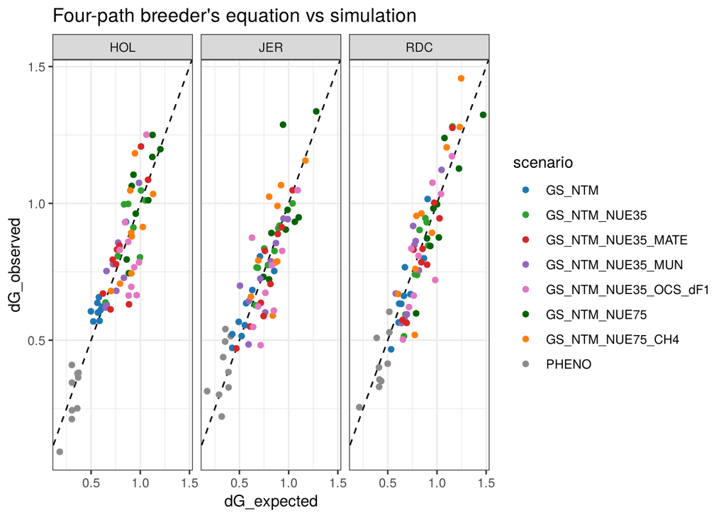

```r
ggplot(beq[!is.na(dG_observed)], aes(dG_expected, dG_observed, colour = scenario)) +
  geom_abline(lty = 2) + geom_point() + scale_colour_manual(values = pal) +
  facet_wrap(~breed) + theme_bw() + labs(title = "Four-path breeder's equation vs simulation")
```

The response is measured on each scenario’s **own** index, so ΔG values are not comparable *between* scenarios; the trait-level table above is the like-for-like comparison.

## 7.3 Correlation of traits with the selection index

```r
if (nrow(idx)) {
  pk(dcast(idx[, .(r = mean(cor_EBV_index)), by = .(scenario, trait)], trait ~ scenario,
              value.var = "r"), digits = 2, caption = "cor(EBV of trait, index), mean over generations")
  pk(dcast(idx[, .(acc = mean(acc_trait)), by = .(scenario, trait)], trait ~ scenario,
              value.var = "acc"), digits = 2, caption = "Accuracy of genomic EBV per trait in candidates")
}
```

cor(EBV of trait, index), mean over generations

| trait | GS_NTM | GS_NTM_NUE35 | GS_NTM_NUE35_MATE | GS_NTM_NUE35_MUN | GS_NTM_NUE35_OCS_dF1 | GS_NTM_NUE75 | GS_NTM_NUE75_CH4 |
| --- | --- | --- | --- | --- | --- | --- | --- |
| CH4 | 0.11 | 0.15 | 0.16 | 0.15 | 0.15 | 0.13 | -0.14 |
| FY | 0.53 | 0.50 | 0.50 | 0.47 | 0.52 | 0.44 | 0.39 |
| ICF | -0.08 | -0.11 | -0.07 | -0.07 | -0.08 | -0.08 | -0.08 |
| LNVAR | 0.03 | 0.02 | 0.05 | 0.04 | 0.02 | 0.03 | 0.01 |
| LONG | 0.10 | 0.15 | 0.16 | 0.15 | 0.14 | 0.15 | 0.18 |
| MUN | 0.07 | 0.06 | 0.05 | -0.18 | 0.05 | 0.08 | 0.04 |
| MY | 0.25 | 0.29 | 0.28 | 0.29 | 0.31 | 0.28 | 0.23 |
| NUE | 0.20 | 0.41 | 0.43 | 0.43 | 0.42 | 0.58 | 0.58 |
| PY | 0.84 | 0.85 | 0.85 | 0.82 | 0.85 | 0.81 | 0.75 |
| SCS | -0.14 | -0.15 | -0.14 | -0.12 | -0.14 | -0.11 | -0.12 |
| SF | 0.37 | 0.36 | 0.34 | 0.31 | 0.35 | 0.30 | 0.33 |

Accuracy of genomic EBV per trait in candidates

| trait | GS_NTM | GS_NTM_NUE35 | GS_NTM_NUE35_MATE | GS_NTM_NUE35_MUN | GS_NTM_NUE35_OCS_dF1 | GS_NTM_NUE75 | GS_NTM_NUE75_CH4 |
| --- | --- | --- | --- | --- | --- | --- | --- |
| CH4 | 0.38 | 0.38 | 0.36 | 0.39 | 0.37 | 0.39 | 0.39 |
| FY | 0.42 | 0.44 | 0.42 | 0.42 | 0.43 | 0.44 | 0.44 |
| ICF | 0.25 | 0.26 | 0.23 | 0.26 | 0.24 | 0.27 | 0.25 |
| LNVAR | 0.42 | 0.43 | 0.40 | 0.43 | 0.44 | 0.40 | 0.43 |
| LONG | 0.27 | 0.27 | 0.23 | 0.23 | 0.27 | 0.25 | 0.28 |
| MUN | 0.40 | 0.40 | 0.38 | 0.40 | 0.37 | 0.39 | 0.39 |
| MY | 0.48 | 0.49 | 0.45 | 0.47 | 0.47 | 0.46 | 0.47 |
| NUE | 0.35 | 0.33 | 0.32 | 0.32 | 0.32 | 0.31 | 0.34 |
| PY | 0.42 | 0.43 | 0.41 | 0.42 | 0.41 | 0.42 | 0.43 |
| SCS | 0.32 | 0.33 | 0.29 | 0.33 | 0.29 | 0.28 | 0.30 |
| SF | 0.40 | 0.40 | 0.36 | 0.40 | 0.41 | 0.44 | 0.39 |

## 7.4 Inbreeding

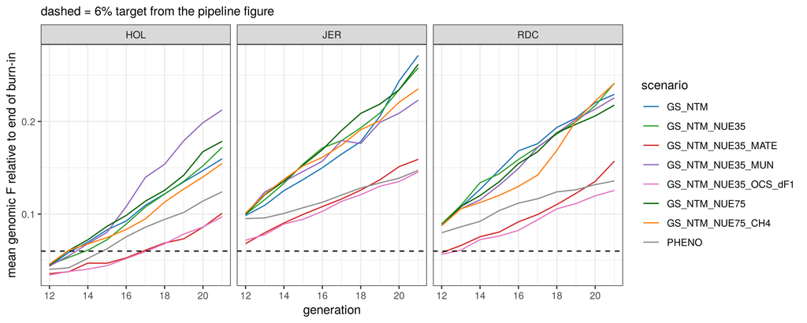

```r
ggplot(Fdt, aes(generation, F_genomic, colour = scenario)) + geom_line() +
  geom_hline(yintercept = 0.06, lty = 2) + scale_colour_manual(values = pal) +
  facet_wrap(~breed) + theme_bw() +
  labs(y = "mean genomic F relative to end of burn-in", subtitle = "dashed = 6% target from the pipeline figure")
```

```r
kable(dcast(Fdt[generation == max(generation)], breed ~ scenario, value.var = "F_genomic"), digits = 3,
      caption = "Genomic inbreeding after 10 generations of selection (level relative to the multi-breed base)")
```

Genomic inbreeding after 10 generations of selection (level relative to the multi-breed base)

| breed | GS_NTM | GS_NTM_NUE35 | GS_NTM_NUE35_MATE | GS_NTM_NUE35_MUN | GS_NTM_NUE35_OCS_dF1 | GS_NTM_NUE75 | GS_NTM_NUE75_CH4 | PHENO |
| --- | --- | --- | --- | --- | --- | --- | --- | --- |
| HOL | 0.160 | 0.172 | 0.101 | 0.212 | 0.097 | 0.179 | 0.155 | 0.124 |
| JER | 0.271 | 0.258 | 0.159 | 0.223 | 0.146 | 0.262 | 0.235 | 0.147 |
| RDC | 0.229 | 0.241 | 0.157 | 0.226 | 0.126 | 0.218 | 0.241 | 0.136 |

```r
# rate of inbreeding per generation: 1 - ((1 - F_T) / (1 - F_0))^(1/T), from the first to the last generation
dF <- Fdt[, .(F0 = F_genomic[generation == min(generation)], FT = F_genomic[generation == max(generation)],
              T = max(generation) - min(generation)), by = .(scenario, breed)]
dF[, dF_per_gen := 1 - ((1 - FT) / (1 - F0))^(1 / T)]
kable(dcast(dF, breed ~ scenario, value.var = "dF_per_gen"), digits = 4,
      caption = "Rate of inbreeding per generation, replicate 0 (FAO guideline: at most 0.01; OCS target: 0.01)")
```

Rate of inbreeding per generation, replicate 0 (FAO guideline: at most 0.01; OCS target: 0.01)

| breed | GS_NTM | GS_NTM_NUE35 | GS_NTM_NUE35_MATE | GS_NTM_NUE35_MUN | GS_NTM_NUE35_OCS_dF1 | GS_NTM_NUE75 | GS_NTM_NUE75_CH4 | PHENO |
| --- | --- | --- | --- | --- | --- | --- | --- | --- |
| HOL | 0.0143 | 0.0157 | 0.0078 | 0.0213 | 0.0075 | 0.0166 | 0.0134 | 0.0101 |
| JER | 0.0234 | 0.0212 | 0.0114 | 0.0163 | 0.0092 | 0.0218 | 0.0178 | 0.0066 |
| RDC | 0.0184 | 0.0201 | 0.0122 | 0.0181 | 0.0084 | 0.0169 | 0.0203 | 0.0069 |

```r
ocs <- rbindlist(lapply(0:(params$n_rep - 1), function(r) rd(sprintf("gs_ocs_GS_NTM_NUE35_OCS_dF1%s.csv", if (r == 0) "" else paste0("_rep", r)), rep_dir(r))), fill = TRUE)
if (nrow(ocs)) kable(ocs[, .(feasible = all(feasible), mean_sires_used = mean(n_sires_used),
                                 max_sire_share = max(max_share),
                                 max_gap_to_target = max(C_achieved - C_target)), by = .(scenario, breed)],
                         digits = 4, caption = "OCS: every generation on target? sires used, largest sire share")
```

OCS: every generation on target? sires used, largest sire share

| scenario | breed | feasible | mean_sires_used | max_sire_share | max_gap_to_target |
| --- | --- | --- | --- | --- | --- |
| GS_NTM_NUE35_OCS_dF1 | HOL | FALSE | 38.22 | 0.1849 | 0.0018 |
| GS_NTM_NUE35_OCS_dF1 | RDC | FALSE | 35.90 | 0.1736 | 0.0007 |
| GS_NTM_NUE35_OCS_dF1 | JER | TRUE | 36.58 | 0.1585 | 0.0000 |

# 8 Replicates: how robust are the scenario differences?

The six main scenarios were each run on up to 10 replicates. **Each replicate has its own coalescent founder population and burn-in** (file 01 with `rep_id` r: seed + r, which also changes the MaCS seed), so the spread between replicates now includes founder sampling, Mendelian sampling, phenotypes, training samples and matings. The same founders and seed are used for every scenario within a replicate, so differences are **paired**.

**NTM value of a response.** For each breed, the genetic change in each trait is divided by its standardisation SD (file 04, `gs_sdA0.csv`), multiplied by that breed’s GS_NTM weight and by 10 (NTM index units per SD), and summed: the change in the *simulated part* of NTM. Multiplied by EUR per NTM unit (HOL 9.9, RDC 9.2, JER 8.0 per cow-year; Fikse & Kargo 2020) it is the extra income per cow-year of daughters at the end, excluding non-simulated sub-indices.

```r
rep_sc <- c("GS_NTM", "GS_NTM_NUE35", "GS_NTM_NUE75", "GS_NTM_NUE35_MUN", ch4_sc, "GS_NTM_NUE35_OCS_dF1")
R <- 0:(params$n_rep - 1)
read_rep <- function(kind, s, r, dir = rep_dir(r))
  rd(sprintf("gs_%s_%s%s.csv", kind, s, if (r == 0) "" else paste0("_rep", r)), dir)
w_ntm <- iw[index == "GS_NTM"]
# response = final generation minus the last burn-in generation OF THE SAME REPLICATE
resp_of <- function(s, r, dir = rep_dir(r)) {
  tr <- read_rep("trend", s, r, dir); tb <- rd("trend_burnin.csv", dir); if (is.null(tr) || is.null(tb)) return(NULL)
  merge(tr[generation == max(generation), .(breed, trait, end = mean_G)],
        tb[generation == max(generation), .(breed, trait, start = mean_G)], by = c("breed", "trait"))[, response := end - start][]
}
reps <- rbindlist(lapply(rep_sc, function(s) rbindlist(lapply(R, function(r) {
  resp <- resp_of(s, r); Fd <- read_rep("inbreeding", s, r); sdA0 <- rd("gs_sdA0.csv", rep_dir(r))
  if (is.null(resp) || is.null(Fd) || is.null(sdA0)) return(NULL)
  v <- merge(merge(resp, sdA0, by = "trait"), w_ntm[, .(breed, trait, w = weight)], by = c("breed", "trait"))
  ntm <- v[, .(NTM = 10 * sum(w * response / sdA0)), by = breed][, EUR := NTM * eur_per_ntm[breed]]
  dF <- Fd[, .(dF = 1 - ((1 - F_genomic[generation == max(generation)]) /
                           (1 - F_genomic[generation == min(generation)]))^(1 / (max(generation) - min(generation)))),
           by = breed]
  out <- dcast(resp[trait %in% c("NUE", "MUN", "CH4", "MY", "PY", "SF", "SCS", "ICF", "LONG")], breed ~ trait, value.var = "response")
  Reduce(function(a, b) merge(a, b, by = "breed"), list(out, ntm, dF))[, `:=`(scenario = s, replicate = r)]
}))))
if (nrow(reps)) {
  # tidy copies for the spreadsheet (NUE_replicate_results.xlsx)
  rep_long <- rbindlist(lapply(rep_sc, function(s) rbindlist(lapply(R, function(r) {
    x <- resp_of(s, r); if (is.null(x)) return(NULL)
    x[trait %in% c("NUE", "MUN", "CH4", "MY", "PY", "SF")][, `:=`(scenario = s, replicate = r,
      source = sprintf("%s/gs_trend_%s%s.csv", rep_dir(r), s, if (r == 0) "" else paste0("_rep", r)))]
  }))))
  fwrite(rep_long, file.path(params$base_dir, "replicate_response_long.csv"))
  fwrite(reps[, .(scenario, replicate, breed, dF, NTM, EUR,
                  source = sprintf("%s/gs_inbreeding_%s%s.csv", sapply(replicate, rep_dir), scenario, ifelse(replicate == 0, "", paste0("_rep", replicate))))],
         file.path(params$base_dir, "replicate_dF.csv"))
  pk(reps[, .(n = uniqueN(replicate)), by = scenario], caption = "Replicates available per scenario")
  long <- melt(reps, id.vars = c("scenario", "replicate", "breed"))
  pk(dcast(long[, .(txt = if (.BY$variable == "dF") sprintf("%.4f +/- %.4f", mean(value), sd(value)) else sprintf("%.2f +/- %.2f", mean(value), sd(value))), by = .(scenario, breed, variable)],
              breed + variable ~ scenario, value.var = "txt"),
        caption = "Response over 10 selection generations (genetic SD; NTM = index units; EUR = per cow-year) and rate of inbreeding (dF): mean +/- SD over replicates")
  pair_test <- function(a, b, v) {
    w <- merge(reps[scenario == a, c("replicate", "breed", v), with = FALSE],
               reps[scenario == b, c("replicate", "breed", v), with = FALSE], by = c("replicate", "breed"))
    if (nrow(w) == 0) return(NULL)
    w[, d := get(paste0(v, ".x")) - get(paste0(v, ".y"))]
    w[, .(n = .N, mean_diff = mean(d), sd_diff = sd(d), same_sign = max(sum(d > 0), sum(d < 0)),
          p_paired = if (.N > 1 && sd(d) > 0) t.test(d)$p.value else NA_real_), by = breed][, comparison := paste(a, "-", b)][, trait := v][]
  }
  pt <- rbindlist(lapply(c("NUE", "MUN", "CH4", "MY", "PY", "SF", "NTM", "EUR", "dF"), function(v) rbind(
    pair_test("GS_NTM_NUE35", "GS_NTM", v), pair_test("GS_NTM_NUE75", "GS_NTM", v),
    pair_test("GS_NTM_NUE35_MUN", "GS_NTM_NUE35", v), pair_test(ch4_sc, ch4_base, v),
    pair_test("GS_NTM_NUE35_OCS_dF1", "GS_NTM_NUE35", v))))
  pk(pt[, .(comparison, trait, breed, n, mean_diff, sd_diff, same_sign, p_paired)], digits = 4,
        caption = "Table A (p-values only). Paired differences between scenarios (same seed within replicate); same_sign = replicates with the majority sign; paired t-test, uncorrected")
  # Correction for multiple testing. One family = all paired tests of this section.
  # EUR is NTM times a constant per breed (the same test), so it is not counted twice and takes the NTM values.
  fam <- pt[trait != "EUR" & !is.na(p_paired)]
  fam[, `:=`(p_BH = p.adjust(p_paired, method = "BH"), p_Bonferroni = p.adjust(p_paired, method = "bonferroni"))]
  pt[fam, on = .(comparison, trait, breed), `:=`(p_BH = i.p_BH, p_Bonferroni = i.p_Bonferroni)]
  pt[fam[trait == "NTM"][, trait := "EUR"], on = .(comparison, trait, breed), `:=`(p_BH = i.p_BH, p_Bonferroni = i.p_Bonferroni)]
  n_fam <- nrow(fam)
  fwrite(pt, file.path(params$base_dir, "paired_tests_multiple_testing.csv"))
  pk(pt[, .(comparison, trait, breed, n, mean_diff, p_paired, p_BH, p_Bonferroni)], digits = 4,
     caption = sprintf("Table B (p-values + corrections). The same tests with Benjamini-Hochberg (false discovery rate) and Bonferroni adjusted p-values; family of %d tests (EUR rows repeat NTM)", n_fam))
  mt_count <- rbind(fam[, .(comparison = "All comparisons", tests = .N, uncorrected = sum(p_paired < 0.05), BH = sum(p_BH < 0.05), Bonferroni = sum(p_Bonferroni < 0.05))],
                    fam[, .(tests = .N, uncorrected = sum(p_paired < 0.05), BH = sum(p_BH < 0.05), Bonferroni = sum(p_Bonferroni < 0.05)), by = comparison])
  pk(mt_count, caption = "Table C. Number of tests significant at 5% under each method")
  verdict <- function(x) ifelse(x < 0.05, "yes", "no")
  key <- fam[(comparison == "GS_NTM_NUE35 - GS_NTM" & trait %in% c("NUE", "NTM")) | (comparison == "GS_NTM_NUE75 - GS_NTM" & trait %in% c("NUE", "NTM")) |
             (comparison == "GS_NTM_NUE35_MUN - GS_NTM_NUE35" & trait %in% c("MUN", "NUE", "NTM")) |
             (comparison == paste(ch4_sc, "-", ch4_base) & trait %in% c("CH4", "NTM")) |
             (comparison == "GS_NTM_NUE35_OCS_dF1 - GS_NTM_NUE35" & trait %in% c("dF", "NTM", "NUE"))]
  pk(key[, .(comparison, trait, breed, mean_diff, p_paired, uncorrected = verdict(p_paired), BH = verdict(p_BH), Bonferroni = verdict(p_Bonferroni))], digits = 4,
     caption = "Table D. Headline results: significant at 5% under each method?")
  lost <- fam[p_paired < 0.05 & p_BH >= 0.05][order(p_paired)]
  pk(lost[, .(comparison, trait, breed, mean_diff, p_paired, p_BH)], digits = 4,
     caption = "Table E. Results below 0.05 uncorrected that do not pass Benjamini-Hochberg (to be read as not established)")
}
```

Replicates available per scenario

| scenario | n |
| --- | --- |
| GS_NTM | 10 |
| GS_NTM_NUE35 | 10 |
| GS_NTM_NUE75 | 10 |
| GS_NTM_NUE35_MUN | 10 |
| GS_NTM_NUE75_CH4 | 10 |
| GS_NTM_NUE35_OCS_dF1 | 10 |

Response over 10 selection generations (genetic SD; NTM = index units; EUR = per cow-year) and rate of inbreeding (dF): mean +/- SD over replicates

| breed | variable | GS_NTM | GS_NTM_NUE35 | GS_NTM_NUE35_MUN | GS_NTM_NUE35_OCS_dF1 | GS_NTM_NUE75 | GS_NTM_NUE75_CH4 |
| --- | --- | --- | --- | --- | --- | --- | --- |
| HOL | CH4 | 1.89 +/- 0.46 | 2.49 +/- 0.45 | 1.99 +/- 0.55 | 1.83 +/- 0.38 | 2.13 +/- 0.21 | 0.54 +/- 0.41 |
| HOL | ICF | 0.85 +/- 0.84 | 1.13 +/- 0.86 | 0.92 +/- 0.70 | 0.94 +/- 0.50 | 1.00 +/- 0.72 | 0.60 +/- 0.62 |
| HOL | LONG | 2.23 +/- 0.64 | 2.75 +/- 0.56 | 2.51 +/- 0.56 | 2.88 +/- 0.42 | 3.16 +/- 0.77 | 2.91 +/- 0.43 |
| HOL | MUN | 1.04 +/- 0.26 | 0.91 +/- 0.46 | -0.51 +/- 0.56 | 0.87 +/- 0.37 | 0.50 +/- 0.37 | 0.38 +/- 0.59 |
| HOL | MY | 3.94 +/- 0.37 | 4.57 +/- 0.57 | 4.30 +/- 0.54 | 4.04 +/- 0.51 | 4.16 +/- 0.47 | 3.67 +/- 0.55 |
| HOL | NUE | 3.40 +/- 0.60 | 4.48 +/- 0.54 | 4.53 +/- 0.55 | 4.35 +/- 0.40 | 4.83 +/- 0.55 | 4.55 +/- 0.53 |
| HOL | PY | 5.27 +/- 0.54 | 6.12 +/- 0.72 | 5.58 +/- 0.59 | 5.61 +/- 0.43 | 5.77 +/- 0.49 | 5.08 +/- 0.56 |
| HOL | SCS | 0.03 +/- 0.48 | 0.42 +/- 0.28 | 0.52 +/- 0.33 | 0.22 +/- 0.22 | 0.36 +/- 0.47 | 0.26 +/- 0.72 |
| HOL | SF | 2.83 +/- 0.54 | 2.88 +/- 0.42 | 2.99 +/- 0.59 | 2.80 +/- 0.50 | 2.48 +/- 0.39 | 2.93 +/- 0.55 |
| HOL | NTM | 59.22 +/- 7.30 | 63.91 +/- 9.10 | 58.88 +/- 6.95 | 60.03 +/- 5.14 | 59.04 +/- 8.19 | 55.05 +/- 8.71 |
| HOL | EUR | 586.29 +/- 72.22 | 632.68 +/- 90.08 | 582.92 +/- 68.80 | 594.26 +/- 50.93 | 584.48 +/- 81.04 | 545.04 +/- 86.21 |
| HOL | dF | 0.0154 +/- 0.0028 | 0.0176 +/- 0.0032 | 0.0173 +/- 0.0023 | 0.0074 +/- 0.0003 | 0.0173 +/- 0.0041 | 0.0169 +/- 0.0043 |
| JER | CH4 | 1.60 +/- 0.71 | 1.94 +/- 0.48 | 1.72 +/- 0.52 | 1.46 +/- 0.40 | 1.65 +/- 0.38 | 0.17 +/- 0.64 |
| JER | ICF | 0.80 +/- 0.44 | 0.90 +/- 0.63 | 0.88 +/- 0.63 | 0.57 +/- 0.33 | 0.79 +/- 0.48 | 0.72 +/- 0.44 |
| JER | LONG | 2.14 +/- 0.51 | 2.98 +/- 0.43 | 2.29 +/- 0.57 | 2.60 +/- 0.56 | 2.84 +/- 0.77 | 2.79 +/- 0.34 |
| JER | MUN | 0.86 +/- 0.57 | 0.86 +/- 0.30 | -0.49 +/- 0.55 | 1.17 +/- 0.28 | 0.62 +/- 0.44 | 0.39 +/- 0.45 |
| JER | MY | 3.67 +/- 0.51 | 3.73 +/- 0.28 | 3.81 +/- 0.75 | 3.38 +/- 0.40 | 3.70 +/- 0.54 | 3.23 +/- 0.52 |
| JER | NUE | 3.40 +/- 0.34 | 4.34 +/- 0.47 | 4.11 +/- 0.41 | 3.63 +/- 0.43 | 4.35 +/- 0.57 | 4.19 +/- 0.28 |
| JER | PY | 5.00 +/- 0.56 | 5.44 +/- 0.46 | 5.09 +/- 0.67 | 4.81 +/- 0.42 | 5.14 +/- 0.48 | 4.58 +/- 0.54 |
| JER | SCS | -0.17 +/- 0.70 | 0.06 +/- 0.50 | 0.19 +/- 0.50 | -0.16 +/- 0.56 | -0.05 +/- 0.63 | 0.02 +/- 0.55 |
| JER | SF | 3.08 +/- 0.50 | 2.66 +/- 0.40 | 2.71 +/- 0.50 | 2.73 +/- 0.51 | 2.58 +/- 0.49 | 3.11 +/- 0.52 |
| JER | NTM | 56.94 +/- 6.27 | 57.45 +/- 6.19 | 53.56 +/- 6.64 | 53.75 +/- 6.06 | 54.09 +/- 6.28 | 50.55 +/- 5.45 |
| JER | EUR | 455.55 +/- 50.13 | 459.57 +/- 49.49 | 428.48 +/- 53.08 | 430.02 +/- 48.46 | 432.69 +/- 50.26 | 404.37 +/- 43.59 |
| JER | dF | 0.0222 +/- 0.0039 | 0.0225 +/- 0.0030 | 0.0223 +/- 0.0051 | 0.0096 +/- 0.0003 | 0.0233 +/- 0.0040 | 0.0188 +/- 0.0034 |
| RDC | CH4 | 2.10 +/- 0.33 | 2.12 +/- 0.35 | 2.00 +/- 0.52 | 2.08 +/- 0.30 | 2.02 +/- 0.41 | 0.59 +/- 0.42 |
| RDC | ICF | 0.91 +/- 0.31 | 1.13 +/- 0.51 | 1.23 +/- 0.47 | 1.12 +/- 0.34 | 1.15 +/- 0.31 | 0.75 +/- 0.51 |
| RDC | LONG | 1.91 +/- 0.47 | 2.44 +/- 0.50 | 2.06 +/- 0.46 | 2.37 +/- 0.47 | 2.71 +/- 0.68 | 2.65 +/- 0.49 |
| RDC | MUN | 0.69 +/- 0.29 | 0.75 +/- 0.45 | -0.49 +/- 0.32 | 0.56 +/- 0.46 | 0.50 +/- 0.56 | 0.19 +/- 0.46 |
| RDC | MY | 3.80 +/- 0.41 | 4.24 +/- 0.29 | 4.15 +/- 0.27 | 3.89 +/- 0.23 | 4.04 +/- 0.52 | 3.70 +/- 0.32 |
| RDC | NUE | 3.32 +/- 0.33 | 4.14 +/- 0.58 | 4.19 +/- 0.50 | 3.96 +/- 0.46 | 4.52 +/- 0.49 | 4.36 +/- 0.45 |
| RDC | PY | 5.07 +/- 0.32 | 5.58 +/- 0.44 | 5.28 +/- 0.31 | 5.23 +/- 0.35 | 5.51 +/- 0.42 | 4.96 +/- 0.37 |
| RDC | SCS | 0.44 +/- 0.41 | 0.63 +/- 0.26 | 0.67 +/- 0.23 | 0.38 +/- 0.51 | 0.60 +/- 0.49 | 0.64 +/- 0.43 |
| RDC | SF | 2.61 +/- 0.28 | 2.50 +/- 0.43 | 2.32 +/- 0.78 | 2.35 +/- 0.48 | 2.53 +/- 0.36 | 2.88 +/- 0.41 |
| RDC | NTM | 61.53 +/- 4.97 | 63.55 +/- 3.89 | 58.86 +/- 6.10 | 60.26 +/- 4.57 | 62.34 +/- 6.51 | 58.35 +/- 6.70 |
| RDC | EUR | 566.03 +/- 45.68 | 584.62 +/- 35.74 | 541.48 +/- 56.12 | 554.41 +/- 42.05 | 573.51 +/- 59.87 | 536.84 +/- 61.67 |
| RDC | dF | 0.0199 +/- 0.0026 | 0.0195 +/- 0.0030 | 0.0185 +/- 0.0020 | 0.0094 +/- 0.0006 | 0.0216 +/- 0.0043 | 0.0192 +/- 0.0022 |

Table A (p-values only). Paired differences between scenarios (same seed within replicate); same_sign = replicates with the majority sign; paired t-test, uncorrected

| comparison | trait | breed | n | mean_diff | sd_diff | same_sign | p_paired |
| --- | --- | --- | --- | --- | --- | --- | --- |
| GS_NTM_NUE35 - GS_NTM | NUE | HOL | 10 | 1.0814 | 0.4423 | 10 | 0.0000 |
| GS_NTM_NUE35 - GS_NTM | NUE | JER | 10 | 0.9362 | 0.6541 | 10 | 0.0014 |
| GS_NTM_NUE35 - GS_NTM | NUE | RDC | 10 | 0.8181 | 0.6405 | 9 | 0.0029 |
| GS_NTM_NUE75 - GS_NTM | NUE | HOL | 10 | 1.4263 | 0.4563 | 10 | 0.0000 |
| GS_NTM_NUE75 - GS_NTM | NUE | JER | 10 | 0.9474 | 0.6778 | 9 | 0.0017 |
| GS_NTM_NUE75 - GS_NTM | NUE | RDC | 10 | 1.1990 | 0.4950 | 10 | 0.0000 |
| GS_NTM_NUE35_MUN - GS_NTM_NUE35 | NUE | HOL | 10 | 0.0505 | 0.4396 | 6 | 0.7246 |
| GS_NTM_NUE35_MUN - GS_NTM_NUE35 | NUE | JER | 10 | -0.2228 | 0.7477 | 6 | 0.3707 |
| GS_NTM_NUE35_MUN - GS_NTM_NUE35 | NUE | RDC | 10 | 0.0526 | 0.3703 | 6 | 0.6640 |
| GS_NTM_NUE75_CH4 - GS_NTM_NUE75 | NUE | HOL | 10 | -0.2771 | 0.6040 | 7 | 0.1808 |
| GS_NTM_NUE75_CH4 - GS_NTM_NUE75 | NUE | JER | 10 | -0.1574 | 0.5041 | 6 | 0.3493 |
| GS_NTM_NUE75_CH4 - GS_NTM_NUE75 | NUE | RDC | 10 | -0.1559 | 0.2995 | 5 | 0.1340 |
| GS_NTM_NUE35_OCS_dF1 - GS_NTM_NUE35 | NUE | HOL | 10 | -0.1328 | 0.4904 | 6 | 0.4140 |
| GS_NTM_NUE35_OCS_dF1 - GS_NTM_NUE35 | NUE | JER | 10 | -0.7008 | 0.5505 | 9 | 0.0030 |
| GS_NTM_NUE35_OCS_dF1 - GS_NTM_NUE35 | NUE | RDC | 10 | -0.1795 | 0.4305 | 6 | 0.2199 |
| GS_NTM_NUE35 - GS_NTM | MUN | HOL | 10 | -0.1292 | 0.4142 | 6 | 0.3497 |
| GS_NTM_NUE35 - GS_NTM | MUN | JER | 10 | -0.0073 | 0.6117 | 5 | 0.9705 |
| GS_NTM_NUE35 - GS_NTM | MUN | RDC | 10 | 0.0598 | 0.4325 | 5 | 0.6722 |
| GS_NTM_NUE75 - GS_NTM | MUN | HOL | 10 | -0.5343 | 0.2777 | 10 | 0.0002 |
| GS_NTM_NUE75 - GS_NTM | MUN | JER | 10 | -0.2436 | 0.7309 | 6 | 0.3193 |
| GS_NTM_NUE75 - GS_NTM | MUN | RDC | 10 | -0.1932 | 0.6325 | 6 | 0.3593 |
| GS_NTM_NUE35_MUN - GS_NTM_NUE35 | MUN | HOL | 10 | -1.4208 | 0.7142 | 9 | 0.0001 |
| GS_NTM_NUE35_MUN - GS_NTM_NUE35 | MUN | JER | 10 | -1.3432 | 0.6212 | 10 | 0.0001 |
| GS_NTM_NUE35_MUN - GS_NTM_NUE35 | MUN | RDC | 10 | -1.2440 | 0.7348 | 10 | 0.0005 |
| GS_NTM_NUE75_CH4 - GS_NTM_NUE75 | MUN | HOL | 10 | -0.1218 | 0.4447 | 6 | 0.4088 |
| GS_NTM_NUE75_CH4 - GS_NTM_NUE75 | MUN | JER | 10 | -0.2255 | 0.6022 | 7 | 0.2667 |
| GS_NTM_NUE75_CH4 - GS_NTM_NUE75 | MUN | RDC | 10 | -0.3129 | 0.8323 | 5 | 0.2649 |
| GS_NTM_NUE35_OCS_dF1 - GS_NTM_NUE35 | MUN | HOL | 10 | -0.0434 | 0.4220 | 5 | 0.7526 |
| GS_NTM_NUE35_OCS_dF1 - GS_NTM_NUE35 | MUN | JER | 10 | 0.3082 | 0.4503 | 7 | 0.0586 |
| GS_NTM_NUE35_OCS_dF1 - GS_NTM_NUE35 | MUN | RDC | 10 | -0.1884 | 0.7215 | 5 | 0.4302 |

[output cut: 105 more lines]

Table B (p-values + corrections). The same tests with Benjamini-Hochberg (false discovery rate) and Bonferroni adjusted p-values; family of 120 tests (EUR rows repeat NTM)

| comparison | trait | breed | n | mean_diff | p_paired | p_BH | p_Bonferroni |
| --- | --- | --- | --- | --- | --- | --- | --- |
| GS_NTM_NUE35 - GS_NTM | NUE | HOL | 10 | 1.0814 | 0.0000 | 0.0004 | 0.0035 |
| GS_NTM_NUE35 - GS_NTM | NUE | JER | 10 | 0.9362 | 0.0014 | 0.0086 | 0.1722 |
| GS_NTM_NUE35 - GS_NTM | NUE | RDC | 10 | 0.8181 | 0.0029 | 0.0138 | 0.3519 |
| GS_NTM_NUE75 - GS_NTM | NUE | HOL | 10 | 1.4263 | 0.0000 | 0.0001 | 0.0005 |
| GS_NTM_NUE75 - GS_NTM | NUE | JER | 10 | 0.9474 | 0.0017 | 0.0095 | 0.2005 |
| GS_NTM_NUE75 - GS_NTM | NUE | RDC | 10 | 1.1990 | 0.0000 | 0.0004 | 0.0038 |
| GS_NTM_NUE35_MUN - GS_NTM_NUE35 | NUE | HOL | 10 | 0.0505 | 0.7246 | 0.8361 | 1.0000 |
| GS_NTM_NUE35_MUN - GS_NTM_NUE35 | NUE | JER | 10 | -0.2228 | 0.3707 | 0.5295 | 1.0000 |
| GS_NTM_NUE35_MUN - GS_NTM_NUE35 | NUE | RDC | 10 | 0.0526 | 0.6640 | 0.7889 | 1.0000 |
| GS_NTM_NUE75_CH4 - GS_NTM_NUE75 | NUE | HOL | 10 | -0.2771 | 0.1808 | 0.3100 | 1.0000 |
| GS_NTM_NUE75_CH4 - GS_NTM_NUE75 | NUE | JER | 10 | -0.1574 | 0.3493 | 0.5181 | 1.0000 |
| GS_NTM_NUE75_CH4 - GS_NTM_NUE75 | NUE | RDC | 10 | -0.1559 | 0.1340 | 0.2330 | 1.0000 |
| GS_NTM_NUE35_OCS_dF1 - GS_NTM_NUE35 | NUE | HOL | 10 | -0.1328 | 0.4140 | 0.5681 | 1.0000 |
| GS_NTM_NUE35_OCS_dF1 - GS_NTM_NUE35 | NUE | JER | 10 | -0.7008 | 0.0030 | 0.0138 | 0.3594 |
| GS_NTM_NUE35_OCS_dF1 - GS_NTM_NUE35 | NUE | RDC | 10 | -0.1795 | 0.2199 | 0.3615 | 1.0000 |
| GS_NTM_NUE35 - GS_NTM | MUN | HOL | 10 | -0.1292 | 0.3497 | 0.5181 | 1.0000 |
| GS_NTM_NUE35 - GS_NTM | MUN | JER | 10 | -0.0073 | 0.9705 | 0.9705 | 1.0000 |
| GS_NTM_NUE35 - GS_NTM | MUN | RDC | 10 | 0.0598 | 0.6722 | 0.7908 | 1.0000 |
| GS_NTM_NUE75 - GS_NTM | MUN | HOL | 10 | -0.5343 | 0.0002 | 0.0015 | 0.0219 |
| GS_NTM_NUE75 - GS_NTM | MUN | JER | 10 | -0.2436 | 0.3193 | 0.4849 | 1.0000 |
| GS_NTM_NUE75 - GS_NTM | MUN | RDC | 10 | -0.1932 | 0.3593 | 0.5194 | 1.0000 |
| GS_NTM_NUE35_MUN - GS_NTM_NUE35 | MUN | HOL | 10 | -1.4208 | 0.0001 | 0.0012 | 0.0171 |
| GS_NTM_NUE35_MUN - GS_NTM_NUE35 | MUN | JER | 10 | -1.3432 | 0.0001 | 0.0008 | 0.0091 |
| GS_NTM_NUE35_MUN - GS_NTM_NUE35 | MUN | RDC | 10 | -1.2440 | 0.0005 | 0.0032 | 0.0552 |
| GS_NTM_NUE75_CH4 - GS_NTM_NUE75 | MUN | HOL | 10 | -0.1218 | 0.4088 | 0.5681 | 1.0000 |
| GS_NTM_NUE75_CH4 - GS_NTM_NUE75 | MUN | JER | 10 | -0.2255 | 0.2667 | 0.4156 | 1.0000 |
| GS_NTM_NUE75_CH4 - GS_NTM_NUE75 | MUN | RDC | 10 | -0.3129 | 0.2649 | 0.4156 | 1.0000 |
| GS_NTM_NUE35_OCS_dF1 - GS_NTM_NUE35 | MUN | HOL | 10 | -0.0434 | 0.7526 | 0.8440 | 1.0000 |
| GS_NTM_NUE35_OCS_dF1 - GS_NTM_NUE35 | MUN | JER | 10 | 0.3082 | 0.0586 | 0.1153 | 1.0000 |
| GS_NTM_NUE35_OCS_dF1 - GS_NTM_NUE35 | MUN | RDC | 10 | -0.1884 | 0.4302 | 0.5737 | 1.0000 |

[output cut: 105 more lines]

Table C. Number of tests significant at 5% under each method

| comparison | tests | uncorrected | BH | Bonferroni |
| --- | --- | --- | --- | --- |
| All comparisons | 120 | 57 | 42 | 15 |
| GS_NTM_NUE35 - GS_NTM | 24 | 12 | 9 | 1 |
| GS_NTM_NUE75 - GS_NTM | 24 | 10 | 7 | 4 |
| GS_NTM_NUE35_MUN - GS_NTM_NUE35 | 24 | 8 | 6 | 2 |
| GS_NTM_NUE75_CH4 - GS_NTM_NUE75 | 24 | 14 | 11 | 5 |
| GS_NTM_NUE35_OCS_dF1 - GS_NTM_NUE35 | 24 | 13 | 9 | 3 |

Table D. Headline results: significant at 5% under each method?

| comparison | trait | breed | mean_diff | p_paired | uncorrected | BH | Bonferroni |
| --- | --- | --- | --- | --- | --- | --- | --- |
| GS_NTM_NUE35 - GS_NTM | NUE | HOL | 1.0814 | 0.0000 | yes | yes | yes |
| GS_NTM_NUE35 - GS_NTM | NUE | JER | 0.9362 | 0.0014 | yes | yes | no |
| GS_NTM_NUE35 - GS_NTM | NUE | RDC | 0.8181 | 0.0029 | yes | yes | no |
| GS_NTM_NUE75 - GS_NTM | NUE | HOL | 1.4263 | 0.0000 | yes | yes | yes |
| GS_NTM_NUE75 - GS_NTM | NUE | JER | 0.9474 | 0.0017 | yes | yes | no |
| GS_NTM_NUE75 - GS_NTM | NUE | RDC | 1.1990 | 0.0000 | yes | yes | yes |
| GS_NTM_NUE35_MUN - GS_NTM_NUE35 | NUE | HOL | 0.0505 | 0.7246 | no | no | no |
| GS_NTM_NUE35_MUN - GS_NTM_NUE35 | NUE | JER | -0.2228 | 0.3707 | no | no | no |
| GS_NTM_NUE35_MUN - GS_NTM_NUE35 | NUE | RDC | 0.0526 | 0.6640 | no | no | no |
| GS_NTM_NUE35_OCS_dF1 - GS_NTM_NUE35 | NUE | HOL | -0.1328 | 0.4140 | no | no | no |
| GS_NTM_NUE35_OCS_dF1 - GS_NTM_NUE35 | NUE | JER | -0.7008 | 0.0030 | yes | yes | no |
| GS_NTM_NUE35_OCS_dF1 - GS_NTM_NUE35 | NUE | RDC | -0.1795 | 0.2199 | no | no | no |
| GS_NTM_NUE35_MUN - GS_NTM_NUE35 | MUN | HOL | -1.4208 | 0.0001 | yes | yes | yes |
| GS_NTM_NUE35_MUN - GS_NTM_NUE35 | MUN | JER | -1.3432 | 0.0001 | yes | yes | yes |
| GS_NTM_NUE35_MUN - GS_NTM_NUE35 | MUN | RDC | -1.2440 | 0.0005 | yes | yes | no |
| GS_NTM_NUE75_CH4 - GS_NTM_NUE75 | CH4 | HOL | -1.5843 | 0.0000 | yes | yes | yes |
| GS_NTM_NUE75_CH4 - GS_NTM_NUE75 | CH4 | JER | -1.4826 | 0.0000 | yes | yes | yes |
| GS_NTM_NUE75_CH4 - GS_NTM_NUE75 | CH4 | RDC | -1.4305 | 0.0000 | yes | yes | yes |
| GS_NTM_NUE35 - GS_NTM | NTM | HOL | 4.6860 | 0.0381 | yes | no | no |
| GS_NTM_NUE35 - GS_NTM | NTM | JER | 0.5025 | 0.7928 | no | no | no |
| GS_NTM_NUE35 - GS_NTM | NTM | RDC | 2.0197 | 0.2610 | no | no | no |
| GS_NTM_NUE75 - GS_NTM | NTM | HOL | -0.1833 | 0.8461 | no | no | no |
| GS_NTM_NUE75 - GS_NTM | NTM | JER | -2.8573 | 0.0412 | yes | no | no |
| GS_NTM_NUE75 - GS_NTM | NTM | RDC | 0.8120 | 0.6143 | no | no | no |
| GS_NTM_NUE35_MUN - GS_NTM_NUE35 | NTM | HOL | -5.0264 | 0.0375 | yes | no | no |
| GS_NTM_NUE35_MUN - GS_NTM_NUE35 | NTM | JER | -3.8863 | 0.0864 | no | no | no |
| GS_NTM_NUE35_MUN - GS_NTM_NUE35 | NTM | RDC | -4.6890 | 0.0419 | yes | no | no |
| GS_NTM_NUE75_CH4 - GS_NTM_NUE75 | NTM | HOL | -3.9836 | 0.0004 | yes | yes | no |
| GS_NTM_NUE75_CH4 - GS_NTM_NUE75 | NTM | JER | -3.5395 | 0.0152 | yes | yes | no |
| GS_NTM_NUE75_CH4 - GS_NTM_NUE75 | NTM | RDC | -3.9853 | 0.0363 | yes | no | no |
| GS_NTM_NUE35_OCS_dF1 - GS_NTM_NUE35 | NTM | HOL | -3.8811 | 0.0418 | yes | no | no |
| GS_NTM_NUE35_OCS_dF1 - GS_NTM_NUE35 | NTM | JER | -3.6927 | 0.0325 | yes | no | no |
| GS_NTM_NUE35_OCS_dF1 - GS_NTM_NUE35 | NTM | RDC | -3.2832 | 0.0442 | yes | no | no |
| GS_NTM_NUE35_OCS_dF1 - GS_NTM_NUE35 | dF | HOL | -0.0102 | 0.0000 | yes | yes | yes |
| GS_NTM_NUE35_OCS_dF1 - GS_NTM_NUE35 | dF | JER | -0.0128 | 0.0000 | yes | yes | yes |
| GS_NTM_NUE35_OCS_dF1 - GS_NTM_NUE35 | dF | RDC | -0.0101 | 0.0000 | yes | yes | yes |

Table E. Results below 0.05 uncorrected that do not pass Benjamini-Hochberg (to be read as not established)

| comparison | trait | breed | mean_diff | p_paired | p_BH |
| --- | --- | --- | --- | --- | --- |
| GS_NTM_NUE35 - GS_NTM | dF | HOL | 0.0022 | 0.0187 | 0.0521 |
| GS_NTM_NUE75 - GS_NTM | dF | HOL | 0.0019 | 0.0201 | 0.0533 |
| GS_NTM_NUE75 - GS_NTM | SF | JER | -0.5009 | 0.0204 | 0.0533 |
| GS_NTM_NUE35_OCS_dF1 - GS_NTM_NUE35 | MY | RDC | -0.3530 | 0.0204 | 0.0533 |
| GS_NTM_NUE75_CH4 - GS_NTM_NUE75 | SF | JER | 0.5336 | 0.0214 | 0.0545 |
| GS_NTM_NUE75_CH4 - GS_NTM_NUE75 | SF | RDC | 0.3411 | 0.0324 | 0.0782 |
| GS_NTM_NUE35_OCS_dF1 - GS_NTM_NUE35 | NTM | JER | -3.6927 | 0.0325 | 0.0782 |
| GS_NTM_NUE35 - GS_NTM | CH4 | JER | 0.3482 | 0.0326 | 0.0782 |
| GS_NTM_NUE75_CH4 - GS_NTM_NUE75 | NTM | RDC | -3.9853 | 0.0363 | 0.0855 |
| GS_NTM_NUE35_MUN - GS_NTM_NUE35 | NTM | HOL | -5.0264 | 0.0375 | 0.0864 |
| GS_NTM_NUE35 - GS_NTM | NTM | HOL | 4.6860 | 0.0381 | 0.0864 |
| GS_NTM_NUE75 - GS_NTM | NTM | JER | -2.8573 | 0.0412 | 0.0899 |
| GS_NTM_NUE35_OCS_dF1 - GS_NTM_NUE35 | NTM | HOL | -3.8811 | 0.0418 | 0.0899 |
| GS_NTM_NUE35_MUN - GS_NTM_NUE35 | NTM | RDC | -4.6890 | 0.0419 | 0.0899 |
| GS_NTM_NUE35_OCS_dF1 - GS_NTM_NUE35 | NTM | RDC | -3.2832 | 0.0442 | 0.0930 |

**Multiple testing.** The section runs 120 paired tests, so about 6 would fall below 0.05 by chance if no scenario differed. Three readings are given:

| Method | Controls | Rule | Strength | Weakness here |
| --- | --- | --- | --- | --- |
| Uncorrected p (Table A) | Error rate of each single test | p < 0.05 | Most power | Many tests: some “significant” results are chance |
| Benjamini-Hochberg (BH) | False discovery rate: expected share of false results among those declared significant | adjusted p < 0.05 | Keeps power with many tests; proven for independent or positively dependent tests (Benjamini & Hochberg 1995; Benjamini & Yekutieli 2001) | Allows about 5% of the declared results to be false |
| Bonferroni | Family-wise error rate: probability of even one false result | p x number of tests < 0.05 | Strictest guarantee | Assumes the worst case; very low power with 10 replicates and correlated tests |

**Preferred for this study: Benjamini-Hochberg.** The tests are many and dependent (the same 10 replicates, genetically correlated traits), the aim is to screen which scenario differences are consistent rather than to confirm one hypothesis, and replicates are few, so Bonferroni would hide real differences. BH is proven to control the false discovery rate for independent or positively dependent tests; under other forms of dependence it is not guaranteed, which is a further reason to show Bonferroni next to it. Bonferroni is shown as the conservative bound: a result that passes it is beyond reasonable doubt in this simulation. The p-values quoted in the breeding-plan section below are uncorrected; a difference listed in Table E should be read as **not established**.

With n replicates the paired t-test has n - 1 degrees of freedom. All three readings describe consistency across simulated founder populations, not a formal claim about real populations.

**Simulation vs selection-index theory.** The ratio of NUE responses (NUE index / NTM index) from the simulation is compared with the ratio expected from file 00 (true breeding values, infinite population). Agreement checks that the simulated programme behaves as the index design intends; differences come from EBV accuracy, finite population and changing variances.

```r
if (nrow(reps)) {
  sim_ratio <- reps[, .(NUE = mean(NUE), NTM = mean(NTM)), by = .(scenario, breed)]
  sim_ratio <- merge(sim_ratio[scenario %in% c("GS_NTM_NUE35", "GS_NTM_NUE75")],
                     sim_ratio[scenario == "GS_NTM", .(breed, NUE0 = NUE, NTM0 = NTM)], by = "breed")
  sim_ratio[, nue_weight := ifelse(scenario == "GS_NTM_NUE35", 0.35, 0.75)]
  th <- merge(fr[nue_weight %in% c(0.35, 0.75), .(breed, nue_weight, NUE_th = NUE, NTM_th = NTM_pct_of_max / 100)],
              fr[nue_weight == 0, .(breed, NUE0_th = NUE)], by = "breed")
  cmp_th <- merge(sim_ratio, th, by = c("breed", "nue_weight"))
  kable(cmp_th[, .(breed, scenario, NUE_ratio_sim = NUE / NUE0, NUE_ratio_theory = NUE_th / NUE0_th,
                   NTM_ratio_sim = NTM / NTM0, NTM_ratio_theory = NTM_th)], digits = 3,
        caption = "NUE and NTM response relative to GS_NTM: simulation (replicate means) vs selection-index theory")
}
```

NUE and NTM response relative to GS_NTM: simulation (replicate means) vs selection-index theory

| breed | scenario | NUE_ratio_sim | NUE_ratio_theory | NTM_ratio_sim | NTM_ratio_theory |
| --- | --- | --- | --- | --- | --- |
| HOL | GS_NTM_NUE35 | 1.318 | 1.323 | 1.079 | 0.973 |
| HOL | GS_NTM_NUE75 | 1.419 | 1.518 | 0.997 | 0.918 |
| JER | GS_NTM_NUE35 | 1.275 | 1.358 | 1.009 | 0.971 |
| JER | GS_NTM_NUE75 | 1.279 | 1.576 | 0.950 | 0.913 |
| RDC | GS_NTM_NUE35 | 1.246 | 1.265 | 1.033 | 0.978 |
| RDC | GS_NTM_NUE75 | 1.361 | 1.432 | 1.013 | 0.933 |

# 9 Sensitivity: how much do the conclusions rest on the NUE correlations?

Every NUE correlation was multiplied by s = 0 and s = 0.5 (file 00; s = 1 is the main run), and new founders, burn-ins and the GS_NTM and GS_NTM_NUE35 programmes were run for each level (up to 5 replicates per level). s = 0 means NUE is genetically unrelated to every other trait. A third set uses the heritability of the NAV Saved Feed index itself, 0.08 (Lidauer et al., NAV workshop 2026), instead of 0.23 (ReFI).

```r
sens_dir <- function(set, r) paste0(params$base_dir, if (set == "main") "" else paste0("_", set), if (r == 0) "" else paste0("_rep", r))
sens <- rbindlist(lapply(c("NUEx0", "NUEx05", "SFh008", "main"), function(set) rbindlist(lapply(0:(params$n_sens_rep - 1), function(r)
  rbindlist(lapply(c("GS_NTM", "GS_NTM_NUE35"), function(s) {
    x <- resp_of(s, r, sens_dir(set, r)); sd0 <- rd("gs_sdA0.csv", sens_dir(set, r))
    if (is.null(x) || is.null(sd0)) return(NULL)
    v <- merge(merge(x, sd0, by = "trait"), w_ntm[, .(breed, trait, w = weight)], by = c("breed", "trait"))
    merge(merge(x[trait == "NUE", .(breed, NUE = response)], x[trait == "SF", .(breed, SF = response)], by = "breed"),
          v[, .(NTM = 10 * sum(w * response / sdA0)), by = breed], by = "breed")[
      , `:=`(set = set, replicate = r, scenario = s)]
  }))))), fill = TRUE)
if (nrow(sens)) {
  sens[, set_label := c(NUEx0 = "NUE correlations x 0", NUEx05 = "NUE correlations x 0.5",
                        SFh008 = "Saved Feed h2 0.08", main = "main run")[set]]
  sw2 <- dcast(sens, set_label + breed + replicate ~ scenario, value.var = c("NUE", "SF", "NTM"))
  sw2[, `:=`(dNUE = NUE_GS_NTM_NUE35 - NUE_GS_NTM, dNTM = NTM_GS_NTM_NUE35 - NTM_GS_NTM)]
  sens_tab <- sw2[, .(n = .N, NUE_under_NTM = mean(NUE_GS_NTM), SF_under_NTM = mean(SF_GS_NTM),
                      NUE_gain_from_weight = mean(dNUE),
                      p_NUE = if (.N > 1 && sd(dNUE) > 0) t.test(dNUE)$p.value else NA_real_,
                      NTM_change = mean(dNTM)), by = .(set_label, breed)][order(breed, set_label)]
  pk(sens_tab, digits = 3, caption = "Sensitivity sets: NUE and Saved Feed response under NTM alone, extra NUE from the 0.35 weight, and NTM change (paired within replicate)")
  th_s <- fread("params/nue_sensitivity_theory.csv")
  pk(th_s, digits = 3, caption = "The same comparison from selection-index theory (file 00)")
}
```

Sensitivity sets: NUE and Saved Feed response under NTM alone, extra NUE from the 0.35 weight, and NTM change (paired within replicate)

| set_label | breed | n | NUE_under_NTM | SF_under_NTM | NUE_gain_from_weight | p_NUE | NTM_change |
| --- | --- | --- | --- | --- | --- | --- | --- |
| NUE correlations x 0 | HOL | 5 | -0.062 | 3.250 | 1.559 | 0.007 | -4.915 |
| NUE correlations x 0.5 | HOL | 5 | 1.953 | 3.101 | 0.638 | 0.033 | -2.011 |
| Saved Feed h2 0.08 | HOL | 5 | 3.413 | 2.236 | 0.963 | 0.006 | 3.300 |
| main run | HOL | 5 | 3.145 | 2.827 | 1.133 | 0.005 | 5.849 |
| NUE correlations x 0 | JER | 5 | -0.137 | 2.830 | 1.610 | 0.008 | -5.046 |
| NUE correlations x 0.5 | JER | 5 | 1.434 | 2.822 | 1.310 | 0.009 | -0.831 |
| Saved Feed h2 0.08 | JER | 5 | 3.534 | 2.241 | 0.674 | 0.056 | -0.820 |
| main run | JER | 5 | 3.408 | 3.123 | 0.766 | 0.025 | 1.107 |
| NUE correlations x 0 | RDC | 5 | 0.131 | 2.744 | 0.726 | 0.077 | -6.542 |
| NUE correlations x 0.5 | RDC | 5 | 1.384 | 2.828 | 1.339 | 0.001 | 0.957 |
| Saved Feed h2 0.08 | RDC | 5 | 3.364 | 1.735 | 0.425 | 0.120 | 1.003 |
| main run | RDC | 5 | 3.247 | 2.384 | 0.669 | 0.019 | 2.029 |

The same comparison from selection-index theory (file 00)

| nue_scale | breed | NUE_GS_NTM | NUE_GS_NTM_NUE35 | NTM_kept_pct |
| --- | --- | --- | --- | --- |
| 0.0 | HOL | 0.000 | 0.319 | 94.761 |
| 0.0 | RDC | 0.000 | 0.295 | 95.548 |
| 0.0 | JER | 0.000 | 0.320 | 94.730 |
| 0.5 | HOL | 0.275 | 0.537 | 95.874 |
| 0.5 | RDC | 0.293 | 0.533 | 96.524 |
| 0.5 | JER | 0.262 | 0.528 | 95.788 |
| 1.0 | HOL | 0.551 | 0.729 | 97.299 |
| 1.0 | RDC | 0.586 | 0.741 | 97.827 |
| 1.0 | JER | 0.524 | 0.711 | 97.135 |

**Reading.** If the NUE gain *under NTM alone* falls towards 0 as s goes to 0, NTM improves NUE only through the correlations, and the claim “NTM already improves NUE” depends on the Irish estimates. If the extra gain from the NUE weight stays clearly positive at every s, the recommendation to add an NUE weight does not depend on them.